# Cladistic analysis of Maya king lists

Authors

Affiliation

Joe Roe

[University of Copenhagen](https://ccrs.ku.dk)

Christophe Helmke

[University of Copenhagen](https://ccrs.ku.dk)

Date

February 2, 2026

This document describes the cladistic analysis of Maya king lists from our forthcoming paper:

> Helmke, Christophe, Vepretskii, Sergei, and Roe, Joe. in prep. Towards a Textual Criticism of Classic Maya Historical Sources.

The analysis used 13 king lists, described in terms of 74 categorical traits. One known specimen (MintMus1983.172.40) was excluded as it is only partially recorded. The analysis was performed in R version 4.5.2 (2025-10-31) (R Core Team 2025) and visualised with ggtree (Yu et al. 2017; Yu 2020, 2022).

There are several methods we can use to generate a dendrogram of this data: the simplest, hierarchical clustering, only considers the relative ‘dissimilarity’ between specimens; the unrooted phylogenetic tree introduces the assumption that these dissimilarities are the result of a process of copying-with-error; the rooted phylogenetic tree further assumes that the reconstructed ‘archetype’ is at the base of the tree.

## Hierarchical clustering

Hierarchical clustering, based only on the dissimilarity between specimens.

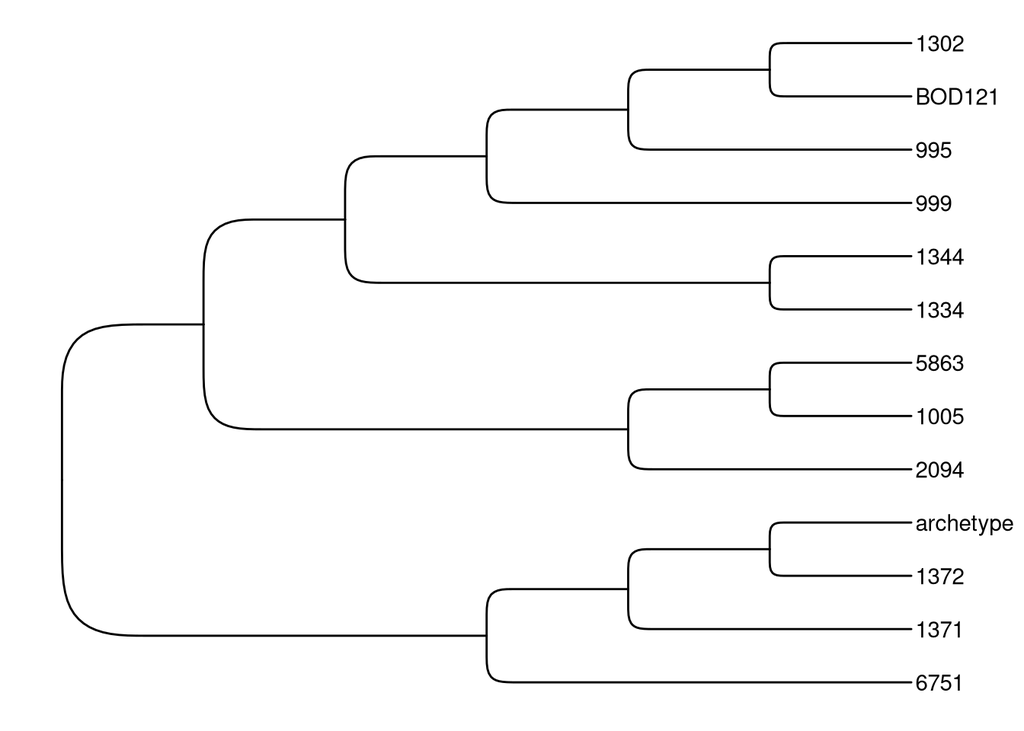

Figure 1: Dendrogram from hierarchical clustering

## Unrooted phylogenetic tree

If we incorporate the assumption that dissimilarities between specimens arose through a process of copying with error (either from each other or from the original), we can generate a more informative tree using phylogenetic methods. We use the ‘branch and bound’ algorithm (Hendy and Penny 1982) to find the most parsimonious trees, i.e. those that require the least number of copying errors. Branch length, indicating the intervening dissimilarity between nodes, was calculated using Grafen’s (1989) method. Phylogenetic analyses were conducted using the R packages ape (Paradis and Schliep 2019) and phangorn (Schliep 2011).

This results in 2 most parsimonious trees. From these we derive the consensus tree, which only includes clades that are found in all most parsiminous trees.

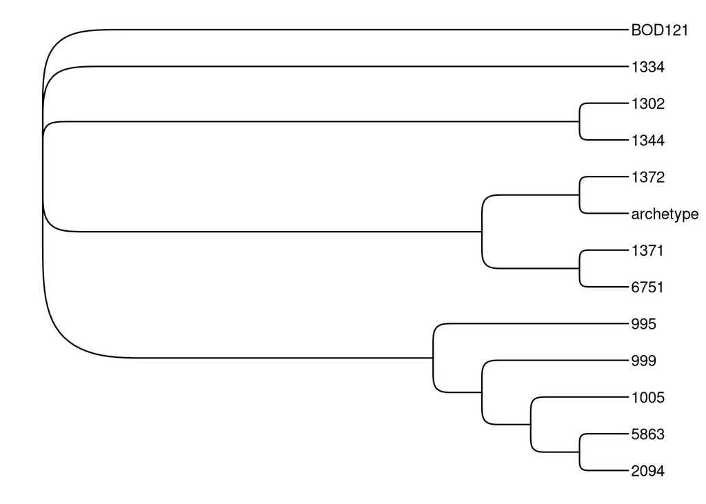

Figure 2: Unrooted consensus phylogenetic tree

The consistency index and retention index are two methods of quantifying how well the observed data fits a phylogenetic model. Both are on a scale of 0 to 1, with 1 being the most ‘tree-like’. For the consensus tree, the consistency index is 0.73 and the retention index is 0.64. This is within the typical range for cultural phylogenies (Collard, Shennan, and Tehrani 2006).

## Rooted phylogenetic tree

Further assuming that the reconstructed archetype is origin of the branching process allows us to ‘root’ the trees above, i.e. ensure that this specimen is the basal branch.

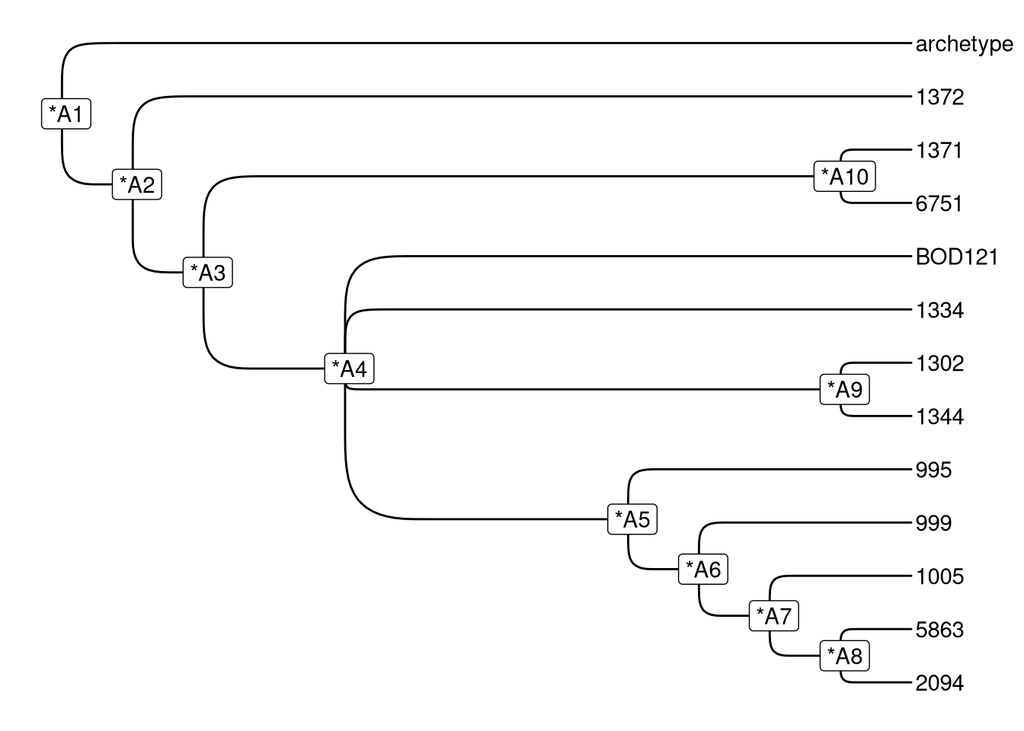

Figure 3: Rooted consensus phylogenetic tree

## Ancestral state reconstruction

Using the rooted consensus tree, we can reconstruct the characteristics of the hypothetical archetypes at the base of each clade, including the basal clade – the putative original. We use the maximum parsimony (MPR) algorithm.

Table 1: Ancestral state reconstruction for inferred archetypes (see Figure 3).

| Ancestral node | R1_coef of Chuwen | R1_phon. comp. bu/wa of Pop | R1_coef. of Pop | R1_verb-ending | R1_CHAN number of dots | R1_nominal with la phon. compl. | R1_EG with phon. comp. | R2_coef of Imix | R2_placement of coef of Imix | R2_coef of Yaxk'in | R2_placement of coef of Yaxk'in | R2_verb-ending | R2_verb + name separate? | R2_orientation of TAJ in name | R2_kalo'mte' after EG? | R2_EG + kalo'mte' separate? | R2_orientation of TE' in kalo'mte' | R3_head-variant form for UX? | R3_coef of Chak-siho'm? | R3_verb deleted? | R3_verb-ending | R3_EG deleted? | R4_geometric form for 3? | R4_coef for Muwaan | R4_Haab TE' num. class. | R4_orientation of num. class. | R4_verb-ending | R4_placement of CHAK (in name) | R4_rendering of CHAK as YAX | … |
| --- | --- | --- | --- | --- | --- | --- | --- | --- | --- | --- | --- | --- | --- | --- | --- | --- | --- | --- | --- | --- | --- | --- | --- | --- | --- | --- | --- | --- | --- | --- |
| *A1 | 7 w/ filler | bu | 19 | la | 2 | la | la | 10 | L | 12 w/ filler | L | la | No | horiz | No | No | none | Ø | 9 | No | la | Yes | No (error 4) | 1 | Yes | vert | la | L | chak | … |
| *A2 | 7 w/ filler | bu | 19 | la | 2 | Ø | la | 10 | L | 12 w/ filler | L | la | No | horiz | No | No | none | Ø | 7 w/ filler | No | la | Yes | No (error 4) | 1 w/ fillers | Yes | vert | la | L | chak | … |
| *A3 | 7 w/ filler | bu | 19 | la | 2 | Ø | la | 10 | L | 12 w/ filler | L | la | No | horiz | No | No | none | Ø | 7 w/ filler | No | la | Yes | No (error 4) | 1 w/ fillers | Yes | vert | la | L | chak | … |
| *A4 | 7 w/ filler | bu | 19 | la | 2 | Ø | la | 10 | L | 10 | L | la | No | horiz | No | No | none | Ø | 7 w/ filler | No | la | Yes | No (error 4) | 1 w/ fillers | Yes | vert | la | L | chak | … |
| *A5 | 12 w/ filler | bu | 19 | la | 2 | Ø | la | 12 w/ filler | L | 10 | L | la | No | horiz | No | No | none | Ø | 12 w/ filler | No | la | No | No (error 4) | 9 | Yes | vert | la | L | chak | … |
| *A6 | 12 w/ filler | wa | 19 | wa | 3 | Ø | la | 12 w/ filler | L | 10 | L | wa | No | horiz | No | No | none | Ø | 12 w/ filler | No | wa | No | No (error 4) | 7 w/ filler | Yes | vert | wa | L | chak | … |
| *A7 | 12 w/ filler | wa | 19 | wa | 3 | Ø | la | 12 w/ filler | L | 10 | L | wa | No | horiz | No | No | none | Ø | 12 w/ filler | No | wa | No | No (error 4) | 7 w/ filler | Yes | vert | wa | L | chak | … |
| *A8 | 12 w/ filler | wa | 19 | wa | 3 | la | la | 12 w/ filler | L | 10 | L | wa | No | horiz | No | No | horiz | Ø | 12 w/ filler | No | wa | No | No (error 4) | 7 w/ filler | Yes | horiz | wa | L | chak | … |
| *A9 | 7 w/ filler | bu | 19 | la | 2 | Ø | la | 10 | L | 12 w/ filler | L | la | No | horiz | No | No | none | Ø | 7 w/ filler | No | la | Yes | No (error 4) | 1 w/ fillers | Yes | vert | la | L | chak | … |
| *A10 | 7 w/ filler | bu | 19 | Ø | 10 equal | Ø | la | 10 | L | 12 w/ filler | L | la | No | horiz | No | No | none | Ø | 7 w/ filler | No | Ø | No | No (error 4) | 1 w/ fillers | Yes | vert | la | L | chak | … |

We can also use this to visualise the evolution of a specific trait on the tree – see below.

## Ancestral trait trees

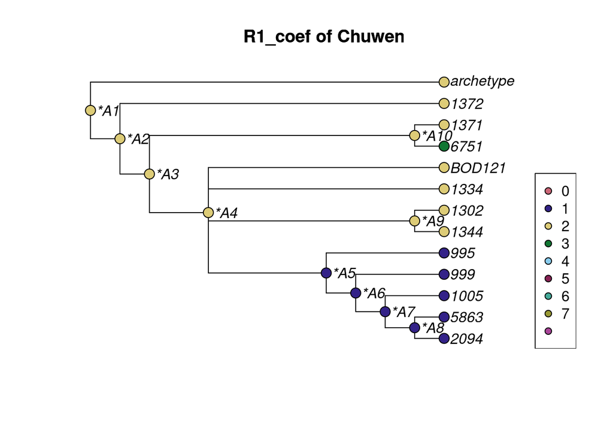

**Legend**

1. 12 w/ filler
2. 7 w/ filler
3. 9 w/o filler

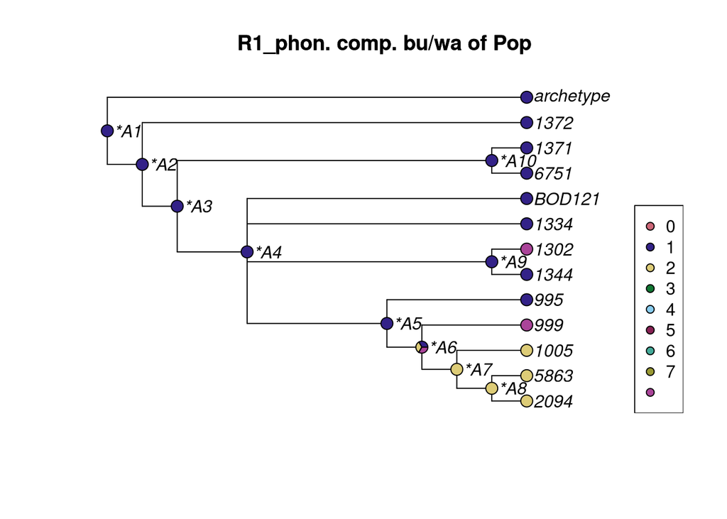

**Legend**

1. bu
2. wa

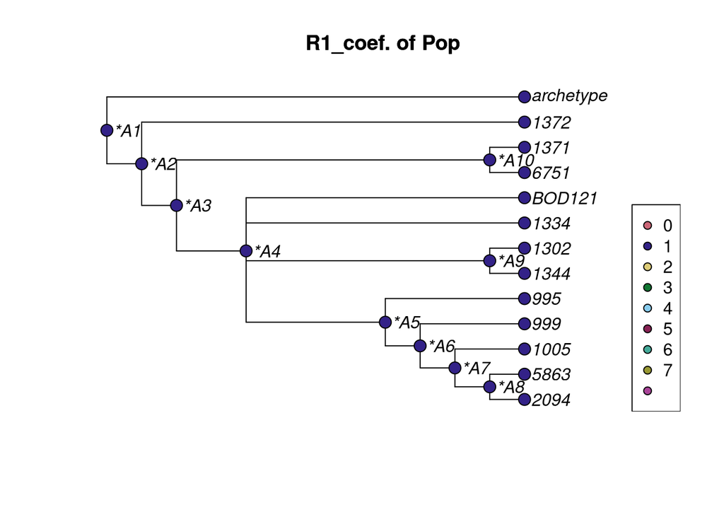

**Legend**

1. 19

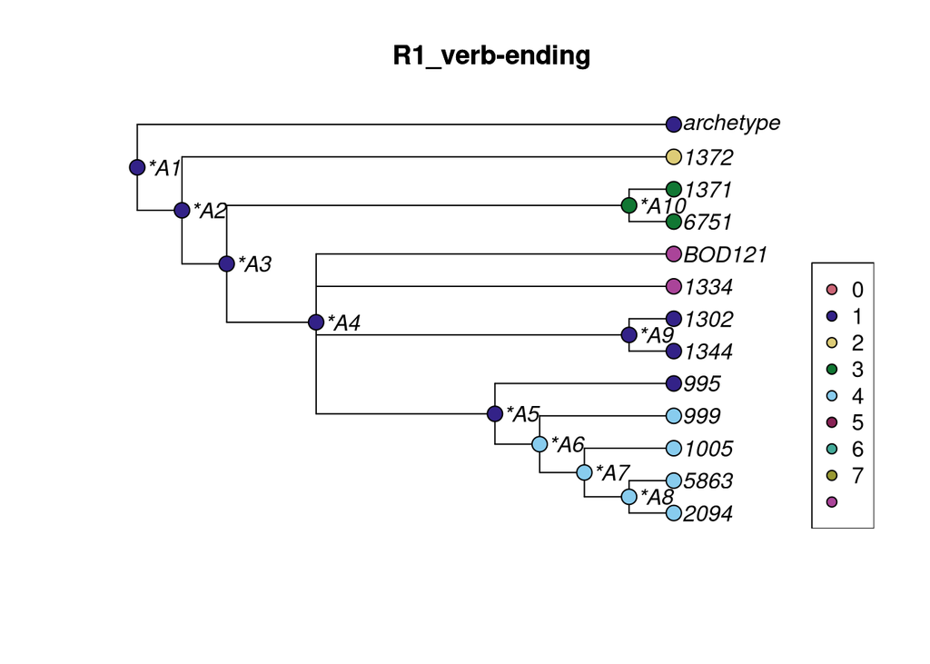

**Legend**

1. la
2. Ø
3. wa
4. ya

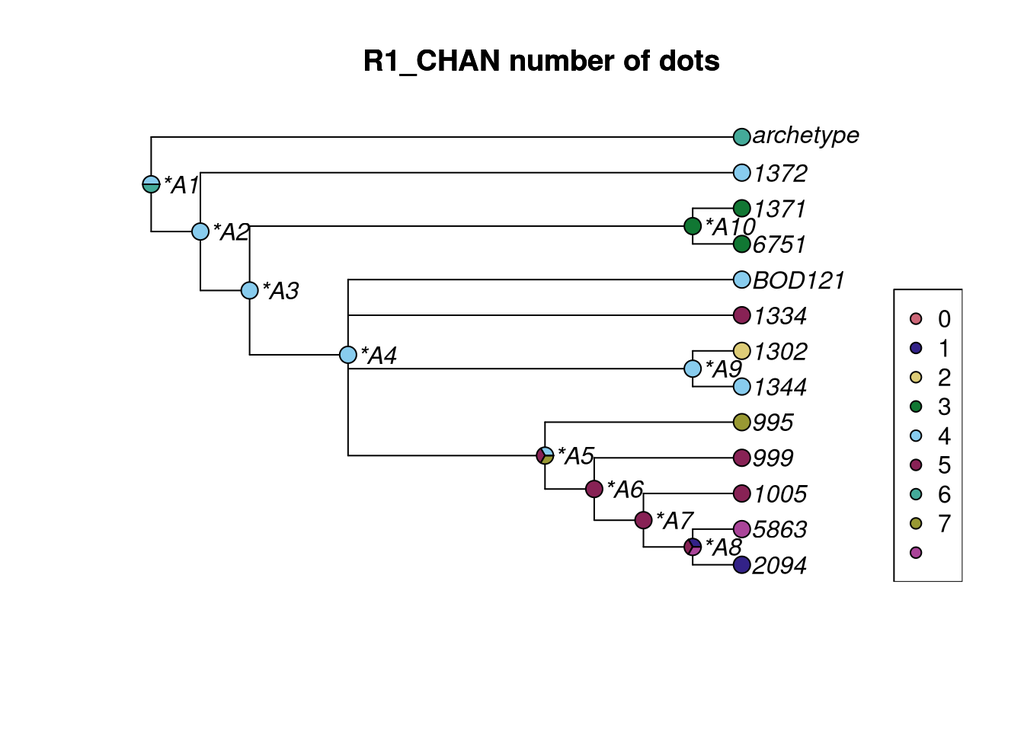

**Legend**

1. 10 equal
2. 2
3. 3
4. 3 main + 2 lateral
5. 3 main + 4 lateral
6. 3 w/ lateral
7. 8 equal

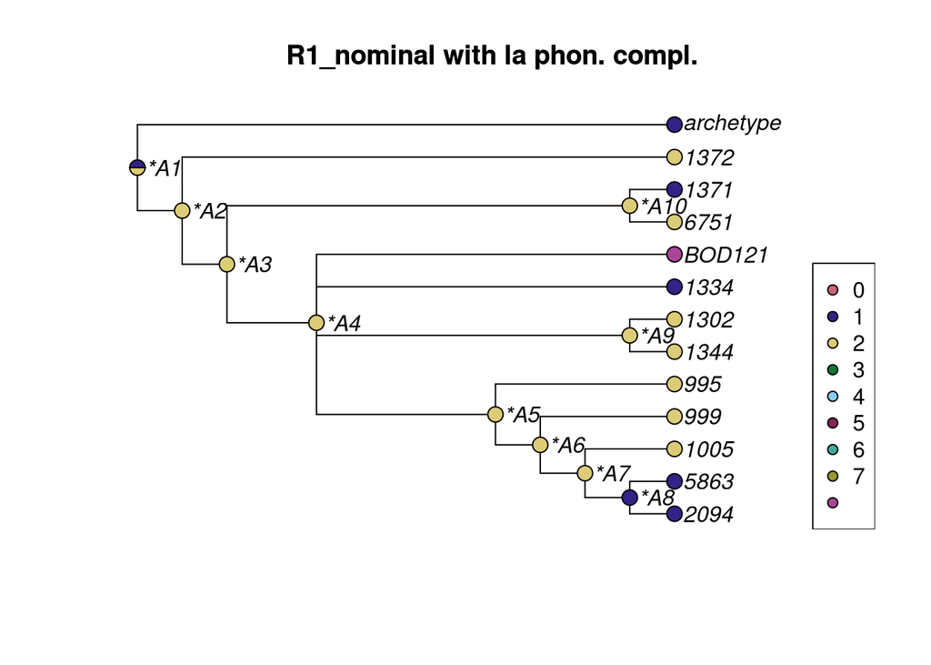

**Legend**

1. la
2. Ø

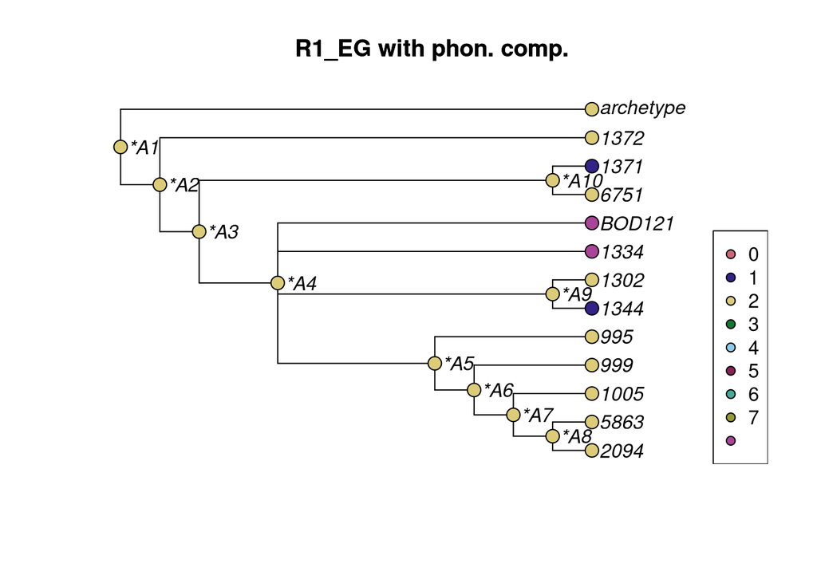

**Legend**

1. la
2. Ø

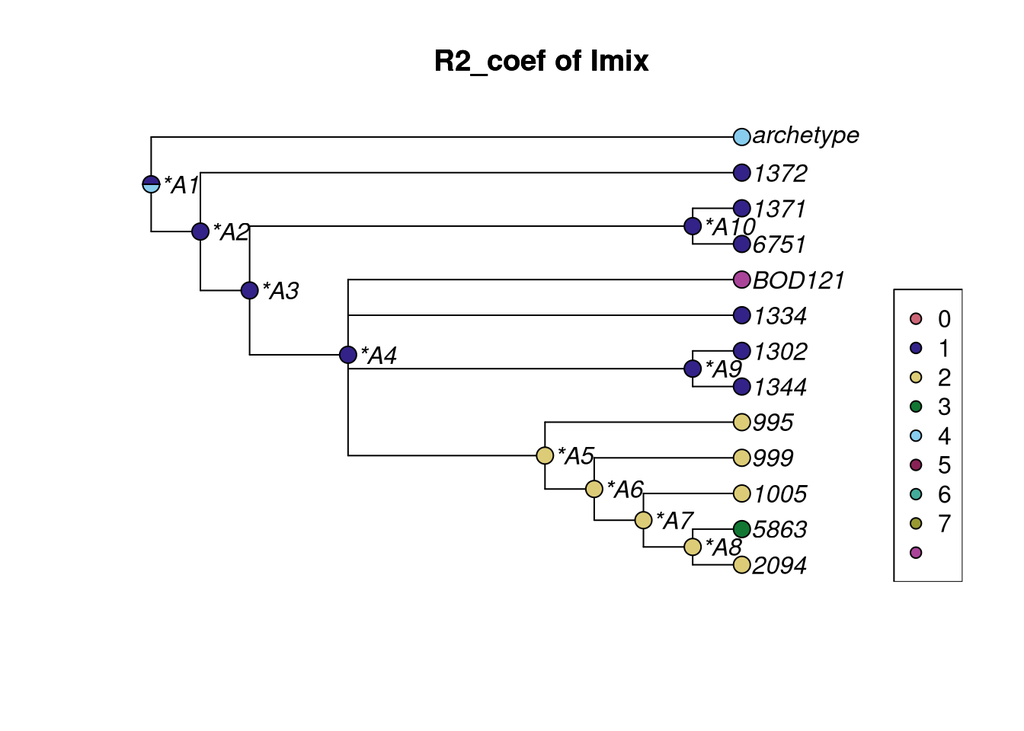

**Legend**

1. 10
2. 12 w/ filler
3. 7 w/ filler
4. 7/10

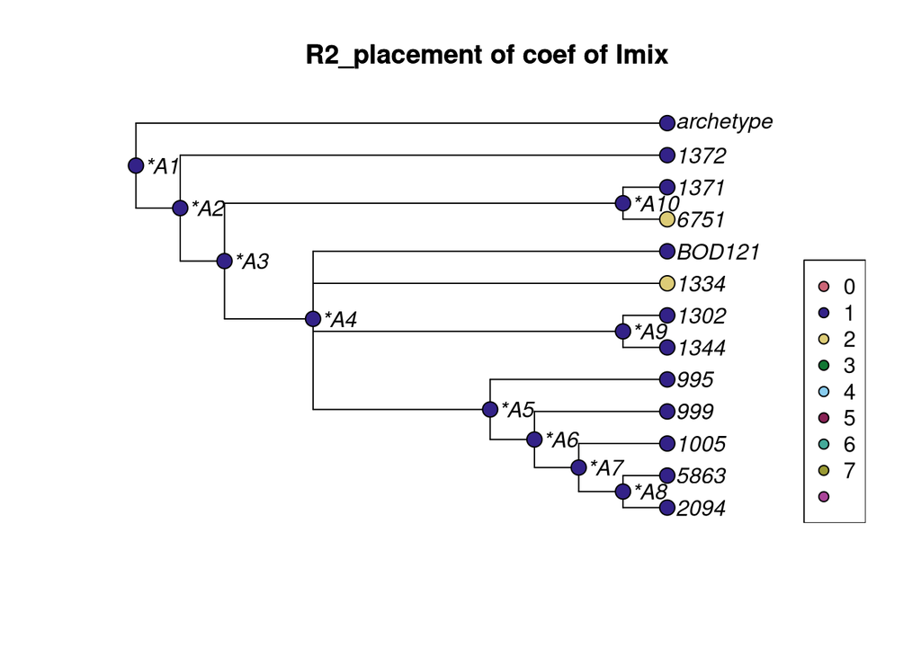

**Legend**

1. L
2. Top

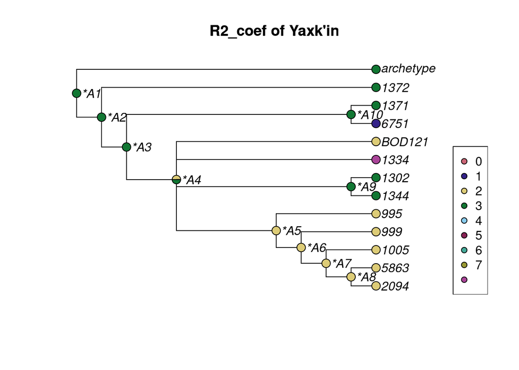

**Legend**

1. 10
2. 12 w/ filler
3. 14

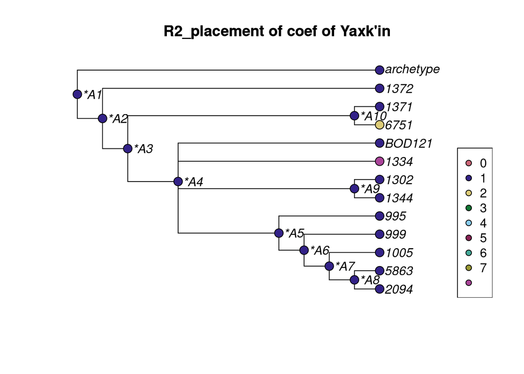

**Legend**

1. L
2. Top

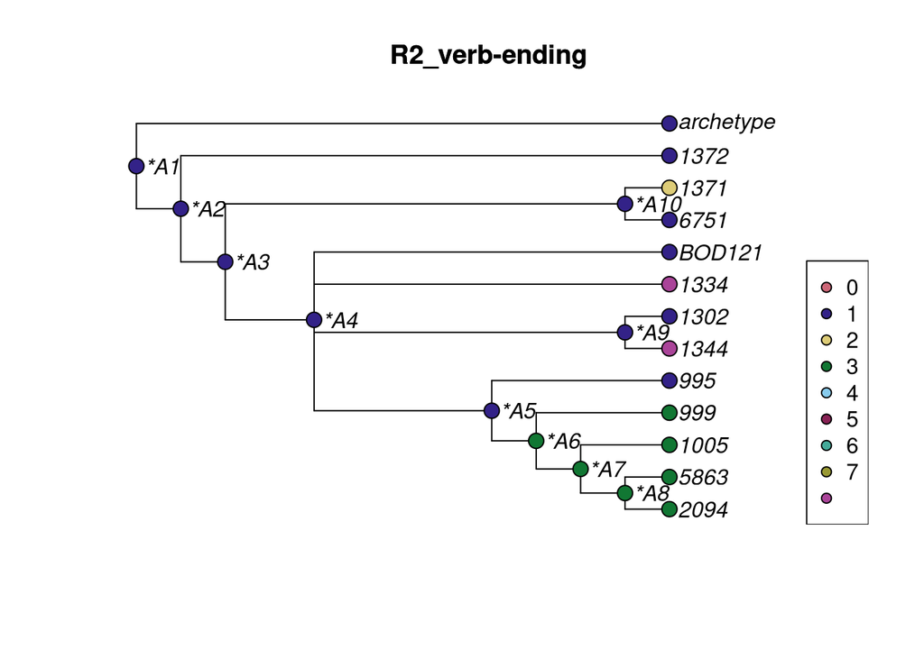

**Legend**

1. la
2. wa
3. ya

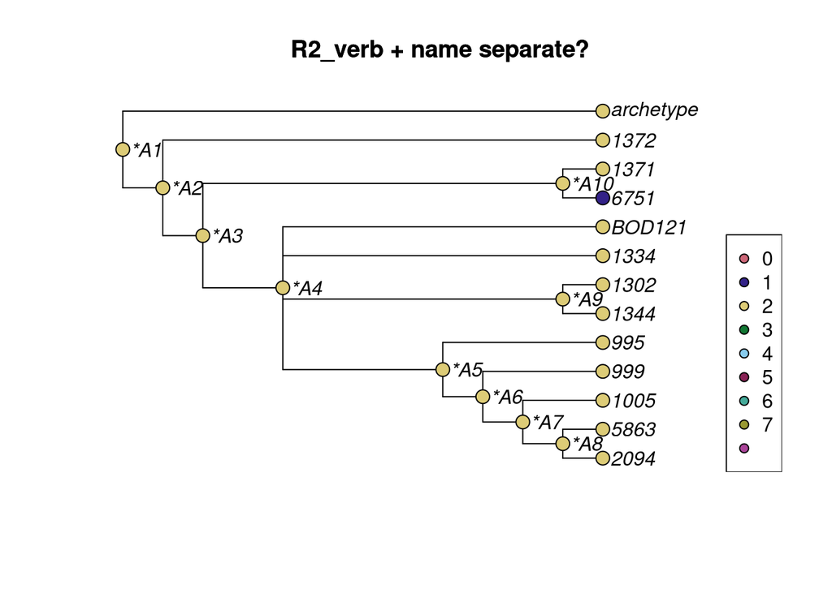

**Legend**

1. No
2. Yes

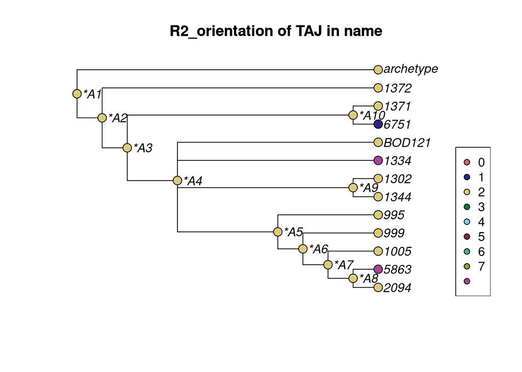

**Legend**

1. horiz
2. vert

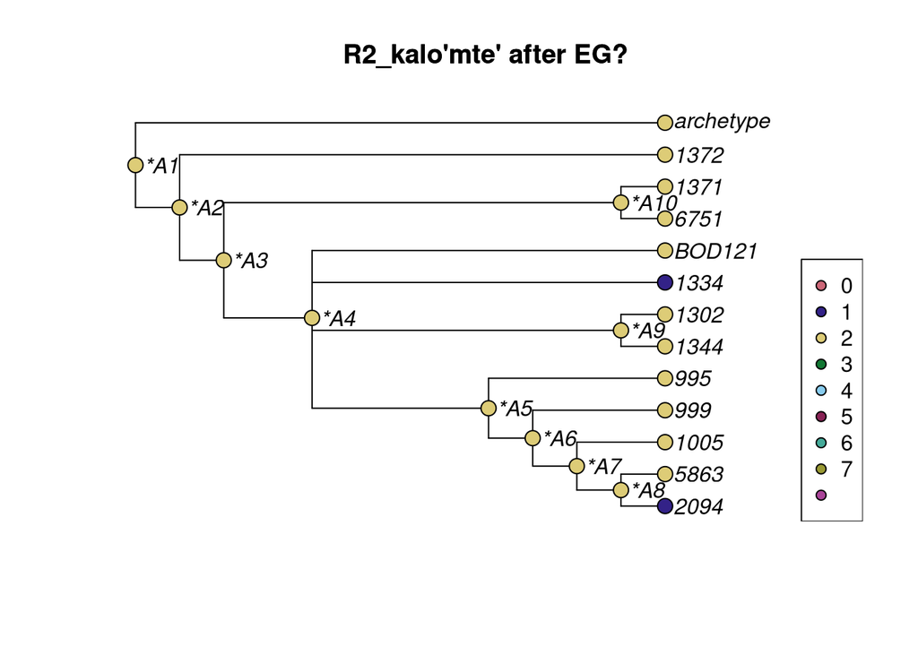

**Legend**

1. No
2. Yes

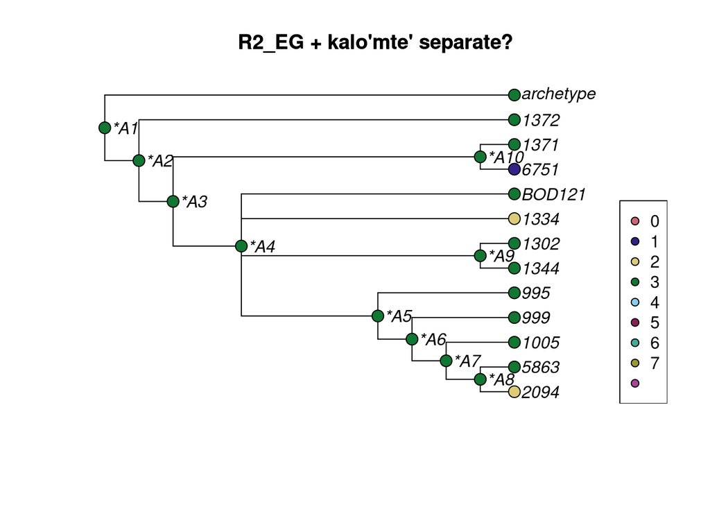

**Legend**

1. No
2. Ø
3. Yes

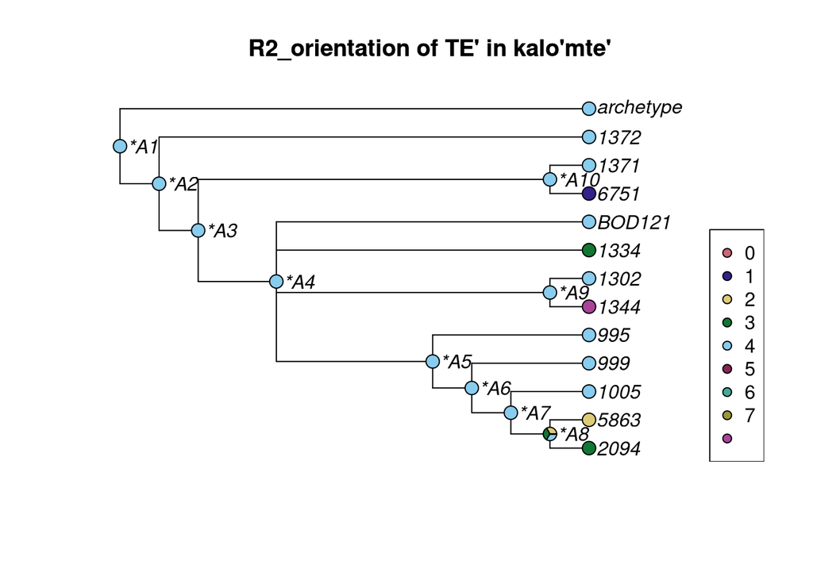

**Legend**

1. horiz
2. none
3. Ø
4. vert

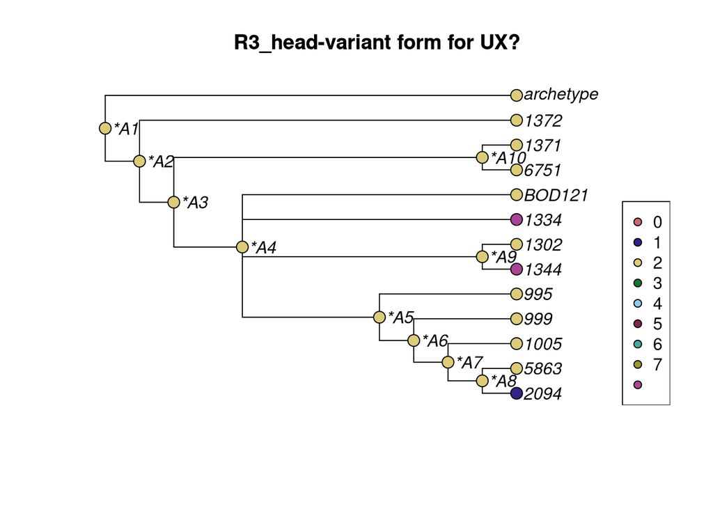

**Legend**

1. Ø
2. Yes

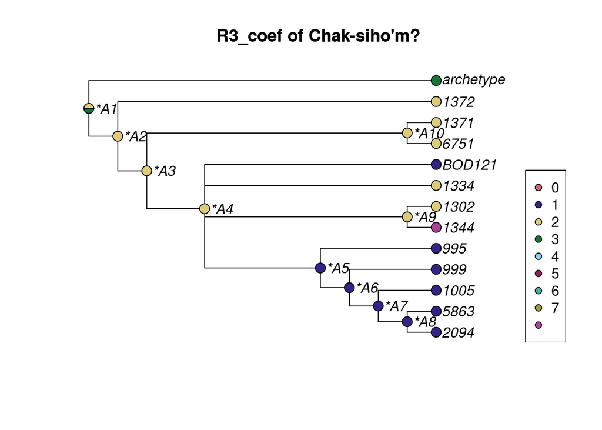

**Legend**

1. 12 w/ filler
2. 7 w/ filler
3. 9

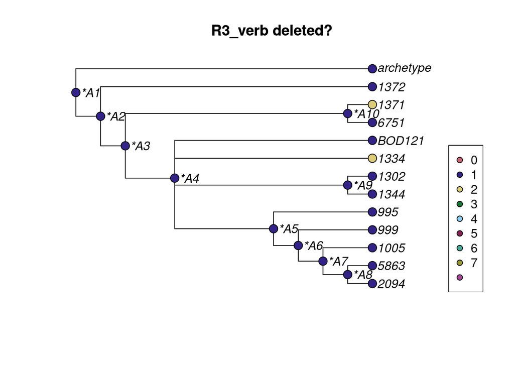

**Legend**

1. No
2. Yes

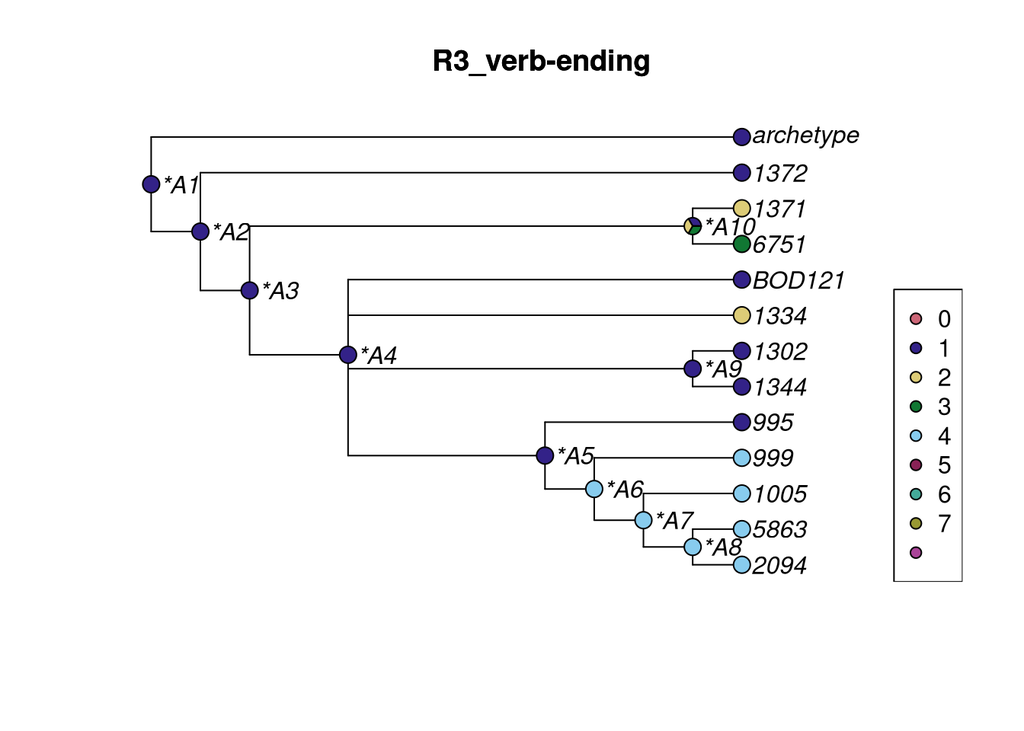

**Legend**

1. la
2. Ø
3. wa
4. ya

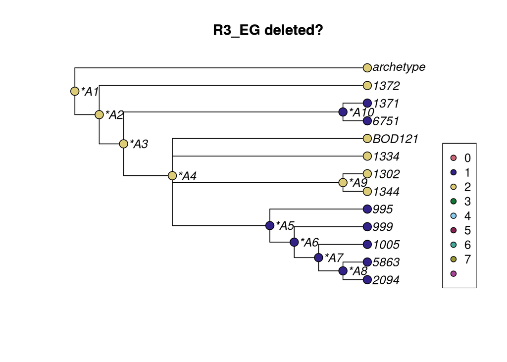

**Legend**

1. No
2. Yes

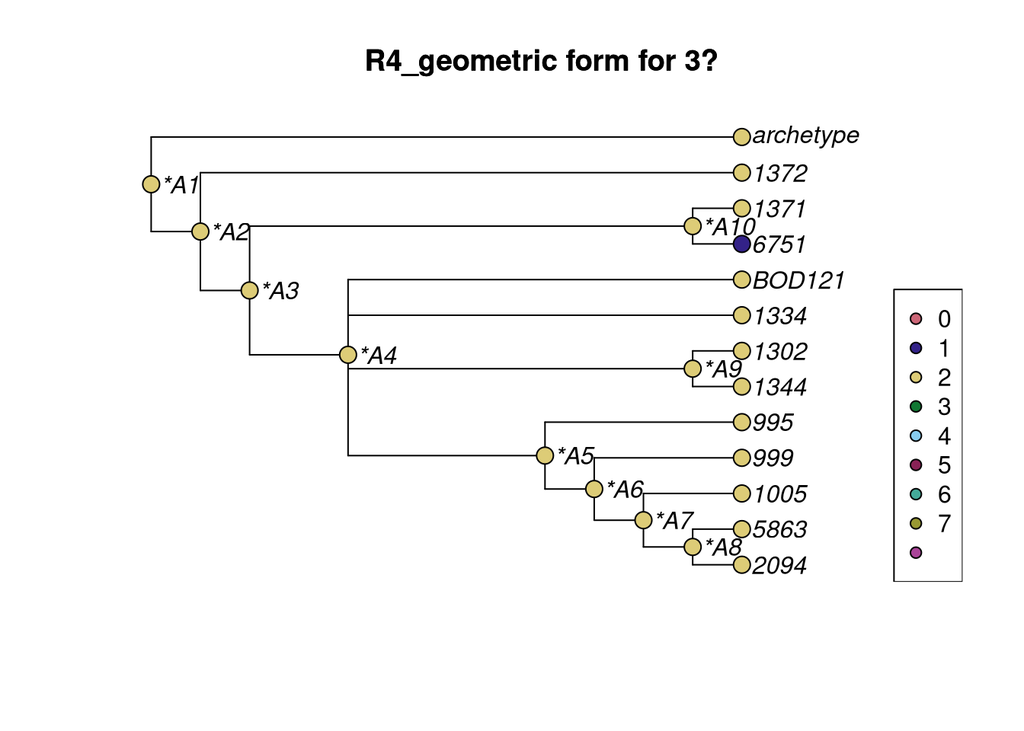

**Legend**

1. No (error 4)
2. Yes

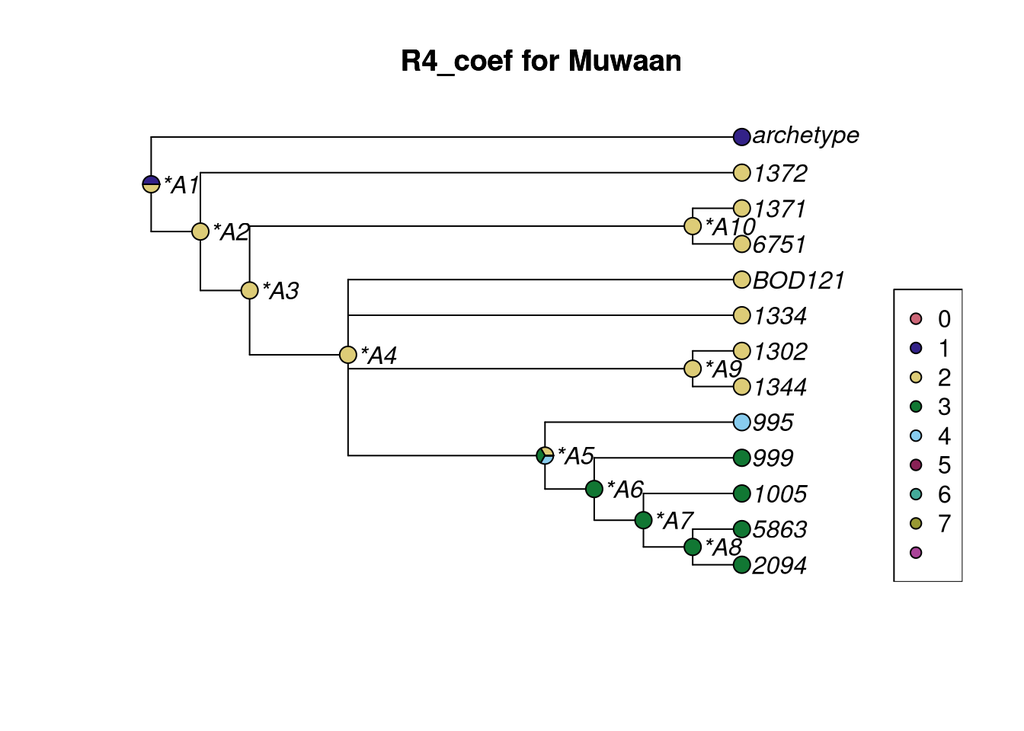

**Legend**

1. 1
2. 1 w/ fillers
3. 7 w/ filler
4. 9

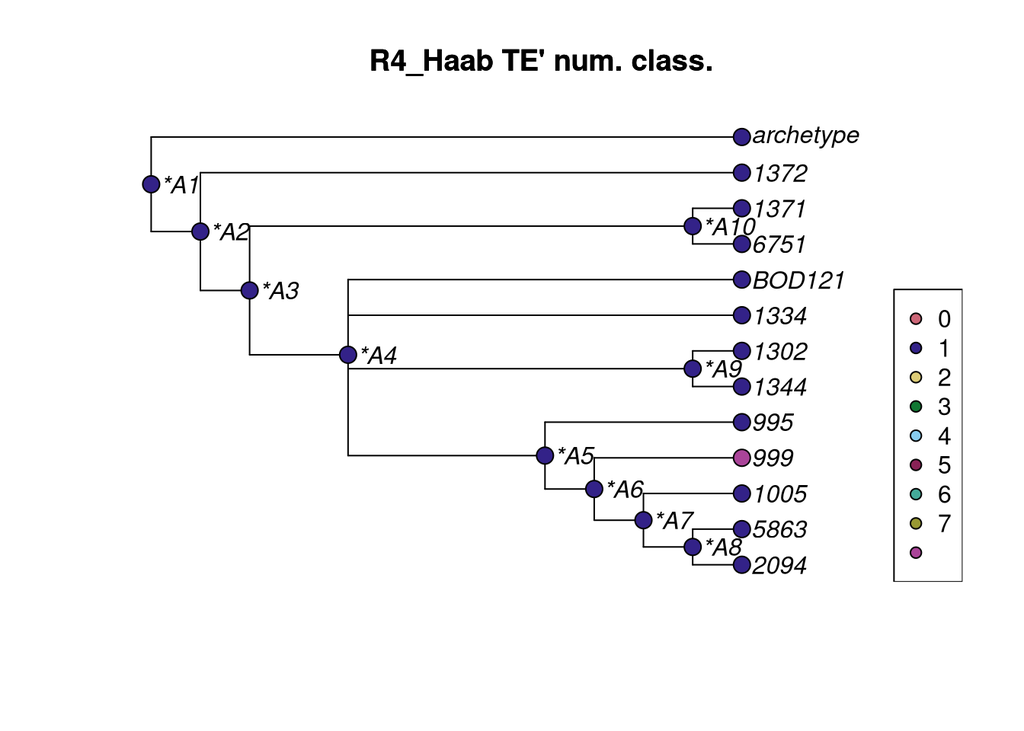

**Legend**

1. Yes

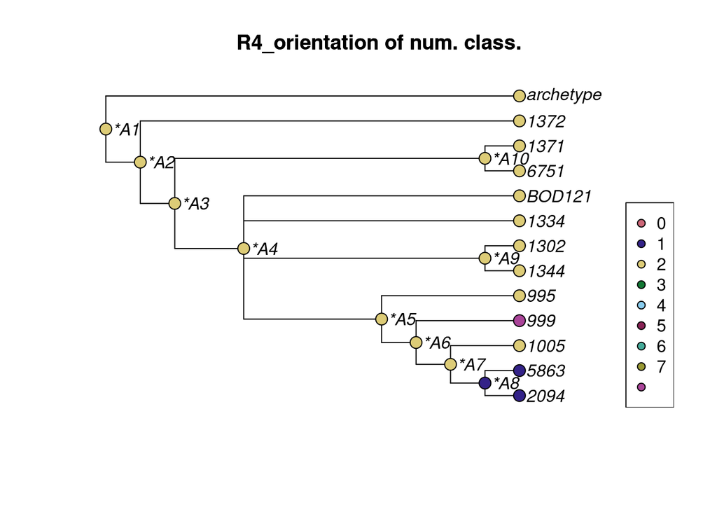

**Legend**

1. horiz
2. vert

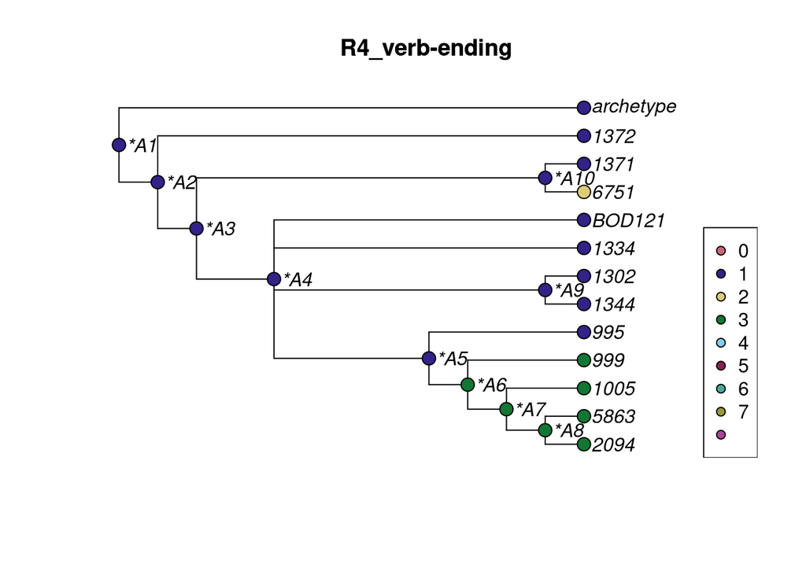

**Legend**

1. la
2. wa
3. ya

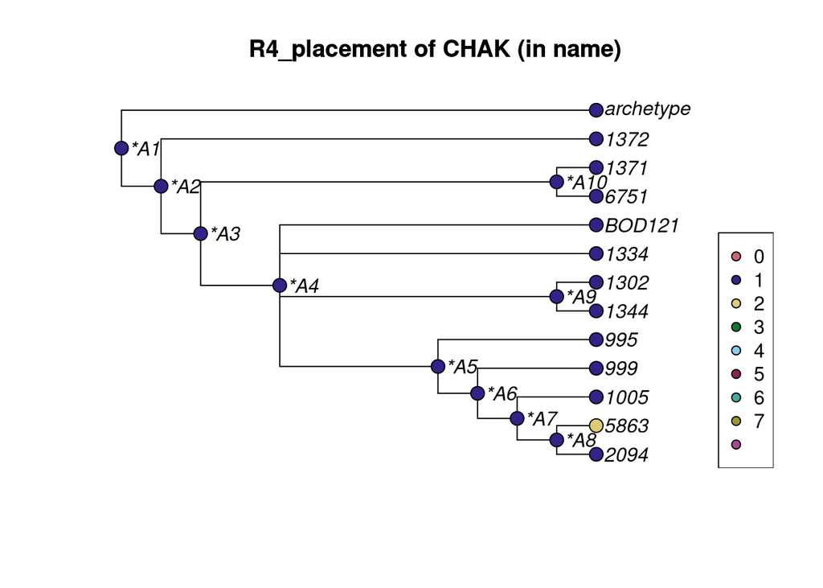

**Legend**